# North Carolina Ozone Concentration Monitoring from 2016 to 2022

https://github.com/KristaPeng/PengYangYu_ENV872_EDA_FinalProject.git

Yanxi Peng & Kaichun Yang & Changxin Yu

# 1 Rationale and Research Questions:

The concentration of tropospheric ozone plays an important role in the atmosphere to global climate change, plant growth and human health. Ozone absorbs solar UVA, UVB irradiation and terrestrial IR irradiation. Also, it’s a strong greenhouse gas whose conctentration trend is highly related to global climate change. The elevation of ozone has been linked to adverse health outcomes in many studies for both of human, animal and plants. Therefore, the long-term trend of ozone concentration is crucial. In class, we used ozone data of North Carolina in 2018 and 2019 and we are interested in how the ozone concentration develops in a longer period at different sites of North Carolina. To study the long-term ozone concentration trend, we used data from 2016 to 2022 and conduct linear regression, time series analysis and spatial analysis with the research questions listed below.

Research Question 1: Is there any correlation between ozone concentration and daily AQI in 2022? The null hypothesis: ozone concentration has no correlation with daily AQI. The alternative hypothesis: ozone concentration has correlation with daily AQI.

Research Question 2: Do different sites have equal mean of ozone concentrations in 2022? The null hypothesis: they have equal mean of concentrations. The alternative hypothesis: they do not have equal mean of concentrations.

Research Question 3: Is the mean of ozone concentrations in 2021 and 2022 equivalent? The null hypothesis: the mean between 2021 and 2022 is equivalent. The alternative hypothesis: the mean between 2021 and 2022 is not equivalent.

Research Question 4: Is there any trend of ozone concentrations in space?

Research Question 5: Have ozone concentrations changed from 2016 to 2022 at Rockwell? The null hypothesis: the ozone concentration is stationary over time. The alternative hypothesis: the ozone concentration change over time.

# 2 Dataset Information:

Here we studied the ozone concentration trend at North Carolina from 2016 to 2022. The datasets were downloaded directly from EPA Outdoor Air Quality Data section (https://www.epa.gov/outdoor-air-quality-data/download-daily-data). The raw data contains detailed information including Date, Source, Site ID, POC, Daily Max, Units etc. Since not all variables are required in our project, we selected the necessary data and form a new dataframe which is comprised of variables including Date, Daily.Max.8.hour.Ozone.Concentration, DAILY_AQI_VALUE, Site.Name, COUNTY, SITE_LATITUDE, SITE_LONGITUDE. After the data selection, we add year and month column for further analysis and fill out NA values in the blank date with linear interpolation.

```
##
##
## Table: The variables of cleaned dataset from raw
##
## |Date       | Concentration | DailyAQI |  SiteName| County|Latitude | Longitude | Month | Year|
## |:----------|:-------------:|:--------:|---------:|------:|:--------|:---------:|:-----:|----:|
## |2016-01-01 |     0.044     |    41    | Cranberry|  Avery|36.1058  | -82.0454  |   1   | 2016|
## |2016-01-02 |     0.045     |    42    | Cranberry|  Avery|36.1058  | -82.0454  |   1   | 2016|
## |2016-01-03 |     0.044     |    41    | Cranberry|  Avery|36.1058  | -82.0454  |   1   | 2016|
## |2016-01-04 |     0.034     |    31    | Cranberry|  Avery|36.1058  | -82.0454  |   1   | 2016|
## |2016-01-05 |     0.040     |    37    | Cranberry|  Avery|36.1058  | -82.0454  |   1   | 2016|
## |2016-01-06 |     0.044     |    41    | Cranberry|  Avery|36.1058  | -82.0454  |   1   | 2016|
```

# 3 Exploratory Analysis:

## 3.1 Obtain basic summaries of the data

```
## [1] 69363    10
```

```
##        X                 Date       Concentration        DailyAQI
##  Min.   :    1   2016-04-11:   40   Min.   :0.00000   Min.   :  0.00
##  1st Qu.:17342   2016-04-14:   40   1st Qu.:0.03400   1st Qu.: 31.00
##  Median :34682   2016-04-15:   40   Median :0.04200   Median : 39.00
##  Mean   :34682   2016-04-16:   40   Mean   :0.04163   Mean   : 39.51
##  3rd Qu.:52023   2016-04-17:   40   3rd Qu.:0.04900   3rd Qu.: 45.00
##  Max.   :69363   2016-04-20:   40   Max.   :0.08800   Max.   :156.00
##                  (Other)   :69123
##    SiteName                 County         Latitude       Longitude
##  Length:69363       Haywood    : 5029   Min.   :34.36   Min.   :-83.80
##  Class :character   Forsyth    : 5024   1st Qu.:35.26   1st Qu.:-82.05
##  Mode  :character   Mecklenburg: 4234   Median :35.55   Median :-80.34
##                     Avery      : 3793   Mean   :35.61   Mean   :-80.35
##                     Cumberland : 3263   3rd Qu.:35.99   3rd Qu.:-78.77
##                     Swain      : 3088   Max.   :36.31   Max.   :-76.62
##                     (Other)    :44932
##      Month             Year
##  Min.   : 1.000   Min.   :2016
##  1st Qu.: 4.000   1st Qu.:2017
##  Median : 6.000   Median :2019
##  Mean   : 6.448   Mean   :2019
##  3rd Qu.: 9.000   3rd Qu.:2021
##  Max.   :12.000   Max.   :2022
##
```

## 3.2 The number of ozone concentrations collected conducted by year and sites

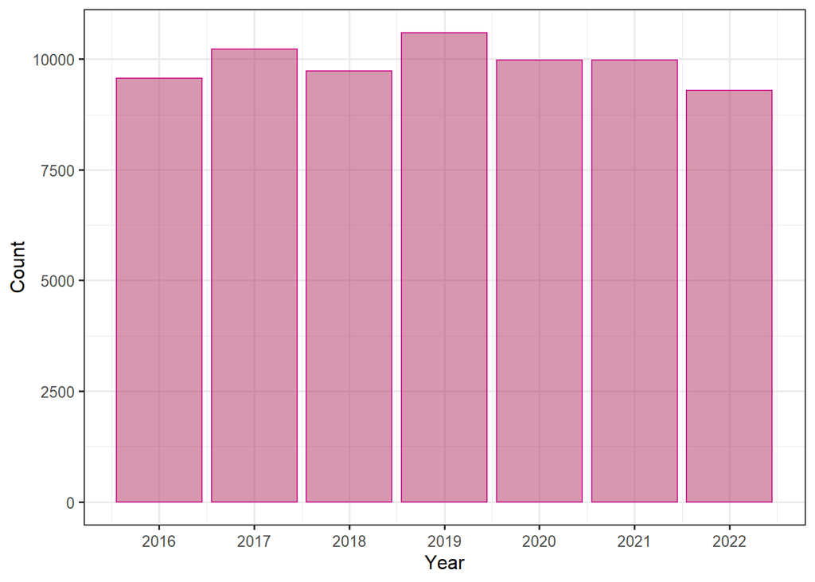

Fig.1 Ozone Concentration Data Distribution in Years

From the Fig.1 bar plot, the number of ozone concentration data collected in the different years is different. For further research, we can either use the newest from the year 2022 or the year that has the most count, which is the year 2019 from this plot.

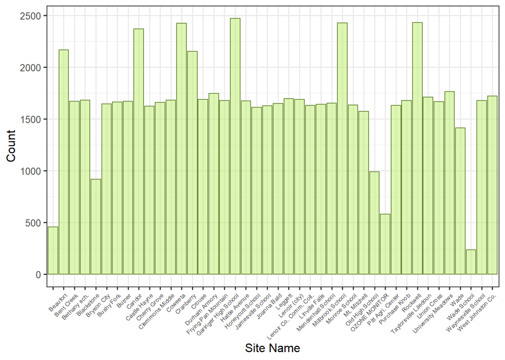

Fig.2 Ozone Concentration Data Distribution in Different Sites

From the Fig.2 bar plot, the number of data samples collected at different sites varied considerably. For further analysis in this project, to ensure the accuracy of the results, we should choose the site with more data extraction as the analysis object. In this case, Garinger high school, Rockwell, Millbrook School, and Coweeta can be considered to use in the data analysis part.

## 3.3 Linear relation between Ozone concentration and daily AQI

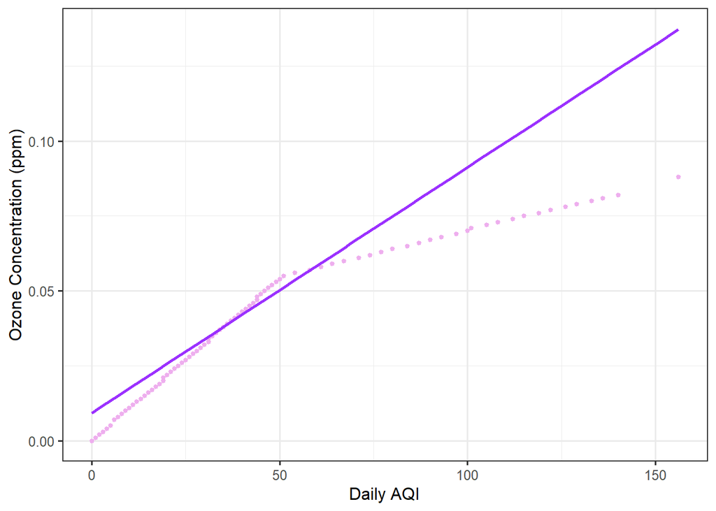

Fig.3 Ozone Concentration vs. Daily AQI

## 3.4 Boxplot:Relationship between O3 Concentration and month (2022)

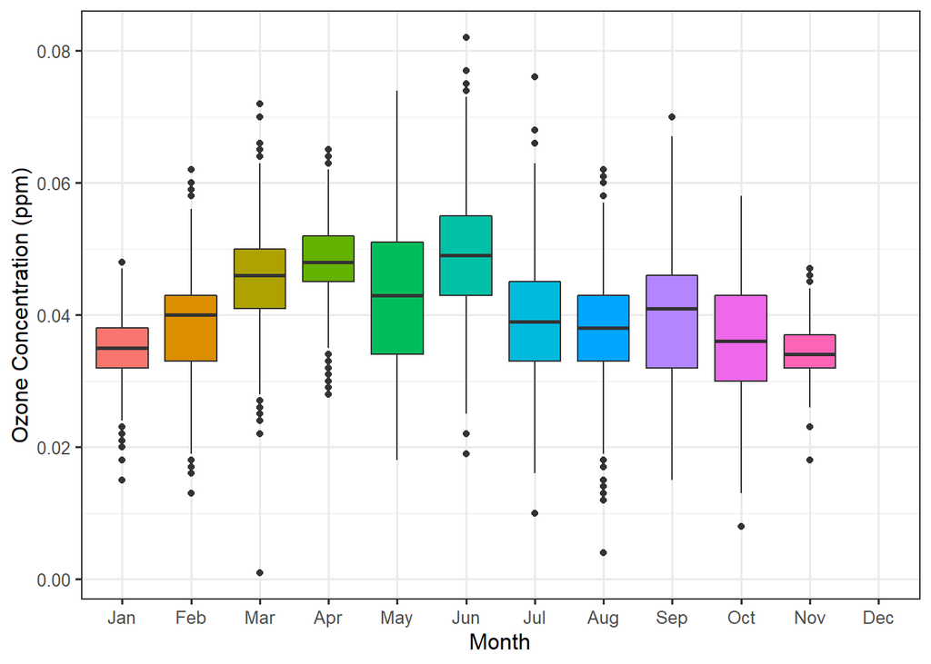

Fig.4 Ozone Concentration vs. Month (2022)

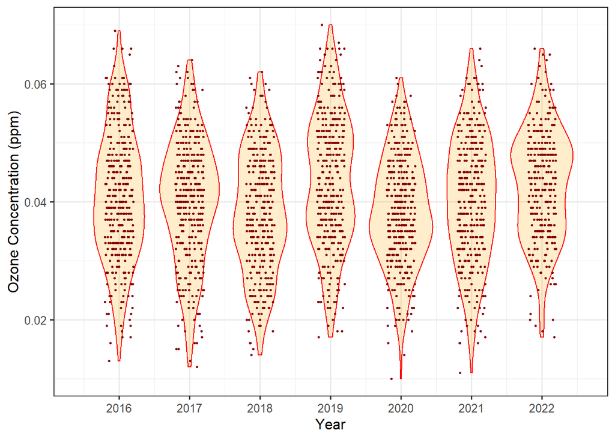

Fig.5 Ozone Concentration vs. Year in Rockwell

Since the distribution of Ozone concentration differs from the site, so we decided to choose Rockwell as our focus. From the Fig.5 violin plot, the ozone concentration values from the year 2016 to 2022 are most gathered around 0.04, and each year has different max and min. To further analyze the change in ozone concentrations from 2016 to 2022, we can apply time series to this research question.

## 3.6 Distribution of concentration at three different sites by years

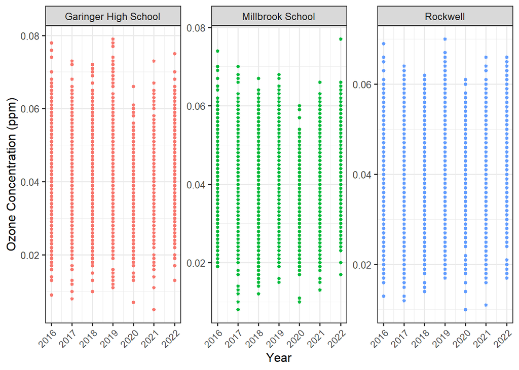

Fig.6 Ozone Concentration vs. Year in Three Sites

We selected the three locations with the maximum counts of concentration value and plot the distribution of concentration by years. And from the Fig.6, we did not observe much difference between different locations. Thus, we could select Rockwell as our main focus.

# 4 Analysis:

## 4.1 Research question 1:

Is there any correlation between ozone concentration and daily AQI in 2022?

The null hypothesis: ozone concentration has no correlation with daily AQI

The alternative hypothesis: ozone concentration has correlation with daily AQI

```
##
## Call:
## lm(formula = Concentration ~ DailyAQI, data = EPAair_O3_22)
##
## Residuals:
##       Min        1Q    Median        3Q       Max
## -0.042585 -0.000866  0.000372  0.001434  0.003672
##
## Coefficients:
##              Estimate Std. Error t value Pr(>|t|)
## (Intercept) 9.350e-03  1.110e-04   84.25   <2e-16 ***
## DailyAQI    8.231e-04  2.688e-06  306.23   <2e-16 ***
## ---
## Signif. codes:  0 '***' 0.001 '**' 0.01 '*' 0.05 '.' 0.1 ' ' 1
##
## Residual standard error: 0.002882 on 9287 degrees of freedom
## Multiple R-squared:  0.9099, Adjusted R-squared:  0.9099
## F-statistic: 9.378e+04 on 1 and 9287 DF,  p-value: < 2.2e-16
```

The R-squared of this linear model is 0.9099, which means that 90.99% variability in daily air quality index (AQI) is explained by changes in ozone concentration. The degrees of freedom of the model is 9287 = 9289-2 since the number of observations is 9289 and the number of parameters is 2. According to the p-value of slope, which is smaller than 0.05, we reject the null hypothesis, so the correlation between ozone concentration and daily AQI in 2022 is significant.

## 4.2 Research question 2:

Do different sites have equal mean of ozone concentrations in 2022?

The null hypothesis: they have equal mean of concentrations

The alternative hypothesis: they do not have equal mean of concentrations

```
## [1] "There are 38 sites in total and 28 of them follow a normal distribution."
```

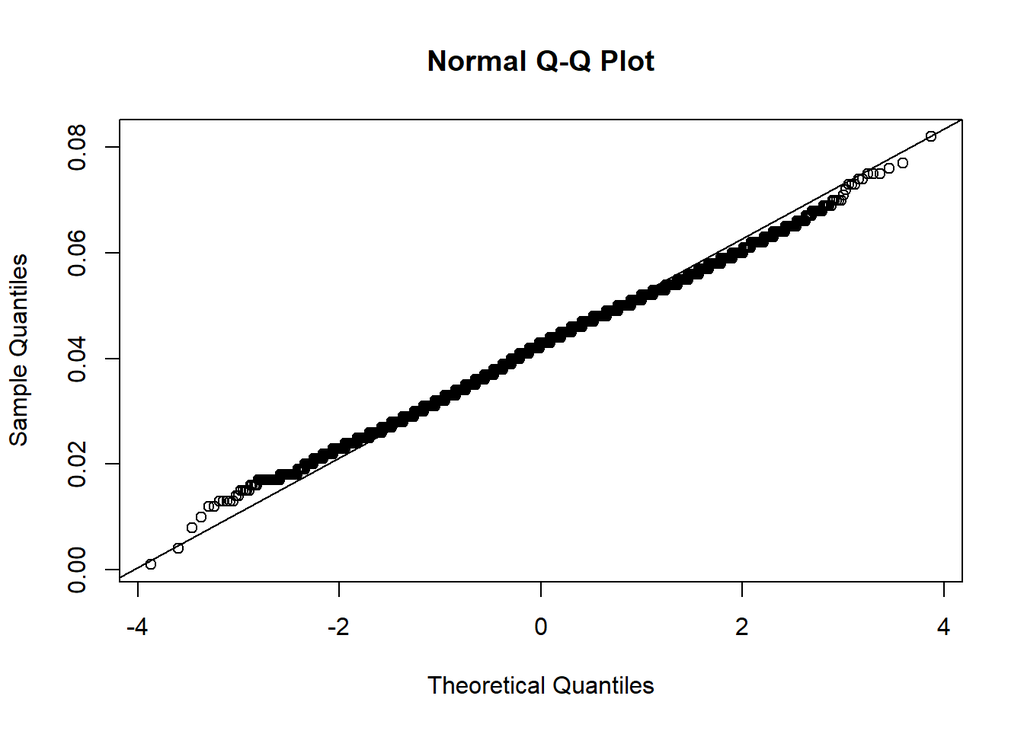

Fig.7 Normal Q-Q Plot for concentrations and sites

```
##
##  Bartlett test of homogeneity of variances
##
## data:  EPAair_O3_22$Concentration and EPAair_O3_22$SiteName
## Bartlett's K-squared = 114.06, df = 37, p-value = 8.769e-10
```

```
##               Df Sum Sq   Mean Sq F value Pr(>F)
## SiteName      37 0.0546 0.0014746   17.02 <2e-16 ***
## Residuals   9251 0.8016 0.0000867
## ---
## Signif. codes:  0 '***' 0.001 '**' 0.01 '*' 0.05 '.' 0.1 ' ' 1
```

From the Shapiro-Wilk test result and normal Q-Q plot, we find that most of the sites are conform to normal population distribution assumption. However, the Bartlett’s test result shows that the null hypothesis that the variances in each sites are the same is rejected. Since ANOVA is robust against departures from equal variance, we can still apply one-way ANOVA on our dataset.

The p-value of the ANOVA is smaller than 0.05, so we reject the null hypothesis. Therefore, the mean of ozone concentrations in 2022 significantly differ among sites.

## 4.3 Research question 3:

Is the mean of ozone concentrations in 2021 and 2022 equivalent?

The null hypothesis: the mean between 2021 and 2022 is equivalent

The alternative hypothesis: the mean between 2021 and 2022 is not equivalent

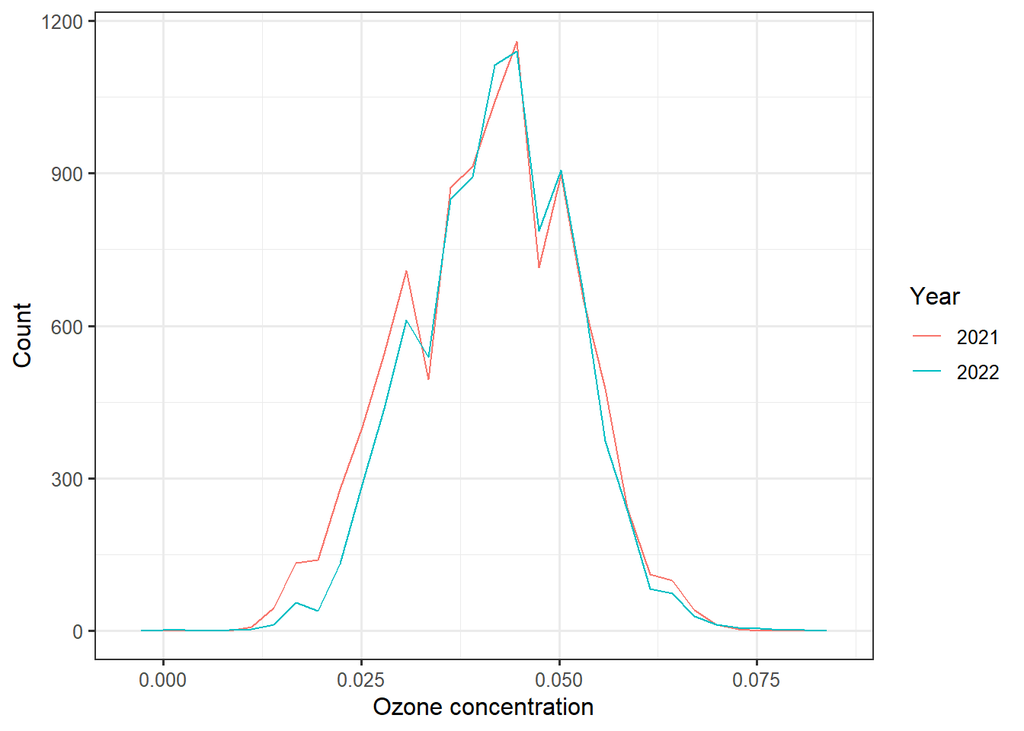

Fig.8 Frequency polygons of ozone in 2021 and 2022

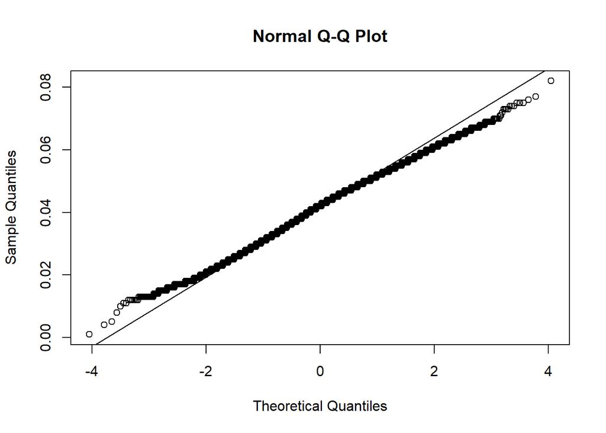

Fig.9 Normal Q-Q Plot for concentrations in 2021 & 2022

```
##
##  Bartlett test of homogeneity of variances
##
## data:  EPAair_O3_2122$Concentration and EPAair_O3_2122$Year
## Bartlett's K-squared = 103.52, df = 1, p-value < 2.2e-16
```

```
##
##  Welch Two Sample t-test
##
## data:  Concentration by Year
## t = -7.0983, df = 19249, p-value = 1.307e-12
## alternative hypothesis: true difference in means between group 2021 and group 2022 is not equal to 0
## 95 percent confidence interval:
##  -0.0013217999 -0.0007497675
## sample estimates:
## mean in group 2021 mean in group 2022
##         0.04104097         0.04207676
```

The normal Q-Q plot shows that the data has small deviations from normal distribution. The Bartlett’s test result shows that the variances between 2021 and 2022 are different. Again, t-test is robust to these. The T-test suggests that the mean of ozone concentrations in 2021 and 2022 is not equivalent with p-value smaller than 0.05.

## 4.4 Research question 4:

Is there any trend of ozone concentrations in space?

[interactive chart not shown]

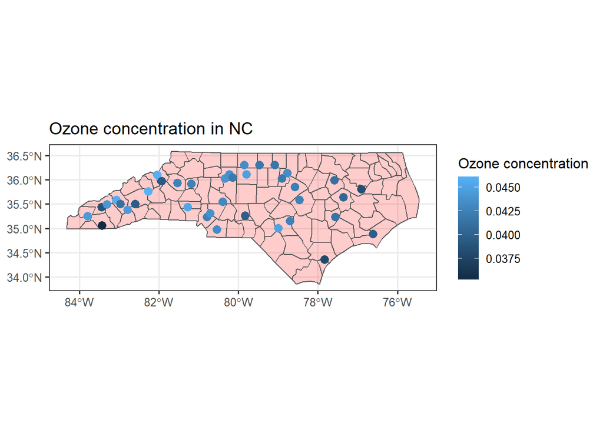

Fig.10 Ozone concentration in NC

It seems there is no obvious trend between the location of sites and the mean ozone concentration collected from the sites.

## 4.5 Research question 5:

Have ozone concentrations changed from 2016 to 2022 at Rockwell?

The null hypothesis: the ozone concentration is stationary over time

The alternative hypothesis: the ozone concentration change over time

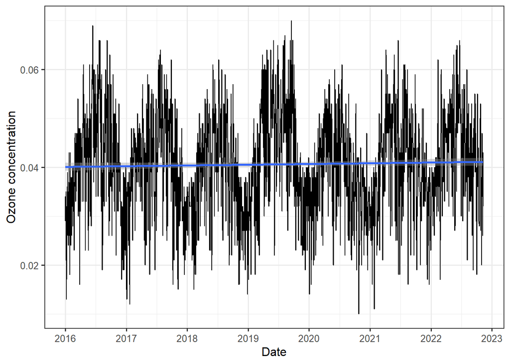

Fig.11 Ozone concentrations at Rockwell from 2016 to 2022

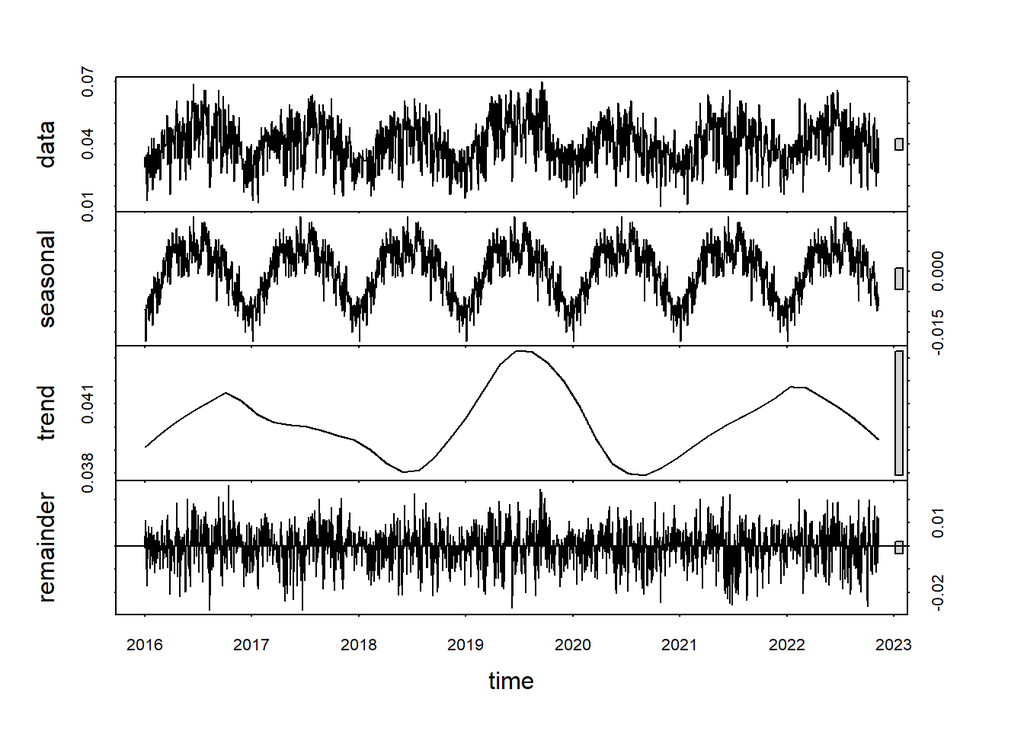

```
## Score =  87 , Var(Score) = 15119
## denominator =  7239.089
## tau = 0.012, 2-sided pvalue =0.47922
```

# 5 Summary and Conclusions:

The Seasonal Mann-Kendall test is chosen to test monotonic trend because the decomposed figure shows that the time series object has a strong seasonal component. From the result, we accept the null hypothesis since the p-value is greater than 0.05. Therefore, the ozone concentration at Rockwell is stationary from 2016 to 2022. To conclude, ozone concentration highly differs among different sites, but we didn’t find trend among geographical regions. Besides, the concentration slightly varies by months but is generally stationary in recent years.